# A Look at Anti-Jewish Hate Crimes Between the Years 1991 and 2019

## Introduction

The last few years have seen a rise in reporting of Anti-Jewish hate crimes, ranging from swasticas in grafitti, verbal harrasment and mass shooting. There have been a number of troubleing mass shootings targeting Jews and Jewish institutions resulting many deaths. The shooting at the Tree of Life synagogue in 2018 left 11 dead and sent shock waves through American Jewish communitty, with may feeling that they were also valnerable agianst such an attack (https://www.vox.com/the-highlight/2019/10/18/20899208/tree-of-life-anniversary-pittsburgh-shooting-american-jews). As an American Jew I want to explore what exactly has been happening in terms of Anti-Jewish hate crime in the U.S. to see if these crimes are really becoming more prevalent of if its just that they are being reported on more often then before. I'm going to bring you along to show you the Data Science Pipeline.

## Getting Started

To get started we want to import all of the libraries that we are going to need to use. The first library we are going to need for this tutorial and arguably the most important is Pandas, which is used to store our data in easy to acess and navigate dataframes. The second libray we are going to need is numpy which we are going to use to make arrays and for other algebric needs in out project. We are going to use matplotlib.pyplot and matplotlib.ticker in order to plot our data. And finally, we are going to use sklearn.linear_model to make and plot a linear regression of our data.

```python
import pandas as pd
import numpy as np
import matplotlib.pyplot as plt
import matplotlib.ticker as ticker
from sklearn.linear_model import LinearRegression
```

## Gathering the Data

I dounloaded the FBI's Hate Crime Statistics dataset for the years 1991-2019 from "https://crime-data-explorer.fr.cloud.gov/pages/downloads". Since the data is saved in a CSV file, we are able to load the data into a dataframe using the Pandas command, read_csv(), and passing in our file's path. Pandas will turn the file into a dataframe which we will be able to veiw and navigate with ease.You can find the pandas documentation here: https://pandas.pydata.org/docs/.

```python
FBI_91_19=pd.read_csv("hate_crime.csv")
FBI_91_19.head()
```

|  | INCIDENT_ID | DATA_YEAR | ORI | PUB_AGENCY_NAME | PUB_AGENCY_UNIT | AGENCY_TYPE_NAME | STATE_ABBR | STATE_NAME | DIVISION_NAME | REGION_NAME | ... | OFFENDER_RACE | OFFENDER_ETHNICITY | VICTIM_COUNT | OFFENSE_NAME | TOTAL_INDIVIDUAL_VICTIMS | LOCATION_NAME | BIAS_DESC | VICTIM_TYPES | MULTIPLE_OFFENSE | MULTIPLE_BIAS |
| --- | --- | --- | --- | --- | --- | --- | --- | --- | --- | --- | --- | --- | --- | --- | --- | --- | --- | --- | --- | --- | --- |
| 0 | 3015 | 1991 | AR0040200 | Rogers | NaN | City | AR | Arkansas | West South Central | South | ... | White | NaN | 1 | Intimidation | 1.0 | Highway/Road/Alley/Street/Sidewalk | Anti-Black or African American | Individual | S | S |
| 1 | 3016 | 1991 | AR0290100 | Hope | NaN | City | AR | Arkansas | West South Central | South | ... | Black or African American | NaN | 1 | Simple Assault | 1.0 | Highway/Road/Alley/Street/Sidewalk | Anti-White | Individual | S | S |
| 2 | 43 | 1991 | AR0350100 | Pine Bluff | NaN | City | AR | Arkansas | West South Central | South | ... | Black or African American | NaN | 1 | Aggravated Assault | 1.0 | Residence/Home | Anti-Black or African American | Individual | S | S |
| 3 | 44 | 1991 | AR0350100 | Pine Bluff | NaN | City | AR | Arkansas | West South Central | South | ... | Black or African American | NaN | 2 | Aggravated Assault;Destruction/Damage/Vandalis... | 1.0 | Highway/Road/Alley/Street/Sidewalk | Anti-White | Individual | M | S |
| 4 | 3017 | 1991 | AR0350100 | Pine Bluff | NaN | City | AR | Arkansas | West South Central | South | ... | Black or African American | NaN | 1 | Aggravated Assault | 1.0 | Service/Gas Station | Anti-White | Individual | S | S |

5 rows × 28 columns

As you can see, all the data has been saved in a data frame. It is broken down into wors and collumns that are easy to call, remove, edit, ect.

# "Cleaning" the Data

As you can see from the dataframe above, the FBI's hate crime statistics provide us with a lot of information regarding each incident. We arn't going to need a lot of those details so we are going to remove those columns from the data frame, that includes "INCIDENT_ID", "ORI", "PUB_AGENCY_NAME", "PUB_AGENCY_UNIT", and "AGENCY_TYPE_NAME".

```python
FBI_91_19=FBI_91_19.drop(columns=["INCIDENT_ID", "ORI", "PUB_AGENCY_NAME",
                                  "PUB_AGENCY_UNIT", "AGENCY_TYPE_NAME"])
```

Since we are interested in Anti_Jewish hate cromes specifically, I'm going to make a new data frame just for Anti-Jewish hate crimes by copying rows from the privious data frame, in which the discription of the bias ("BIAS_DESC") is "Anti-Jewish".

```python
anti_jewish_hc=FBI_91_19[FBI_91_19["BIAS_DESC"] == 'Anti-Jewish']
```

Columns such as "OFFENSE_NAME", "VICTIM_TYPES", and "OFFENDER_RACE" have many differant catagories. Since I don't have documnetation for the data file I don't know what all of the possible options are. I want to know what all of the possible options are to better understand the data. I want a set of all of the seperate options (not combinations) for these catagories. To do that we are going to iterate throught the data frame, split the sting into it's individual options if nessisary, and add the data into a list. Once we have a list of all of the data we are interested in we are going to convert it into a set so we can see all of the unique options.

```python
#Find uniqe offence types
off_typ=[]
for off in set(anti_jewish_hc.iloc[:,16]):
    off_typ.extend(off.split(";"))
off_typ=set(off_typ)
print("Offence types: " + str(off_typ))

#find uniqe victim types
vic_typ=[]
for vic in set(anti_jewish_hc.iloc[:,20]):
    vic_typ.extend(vic.split(";"))
vic_typ=set(vic_typ)
print("Victim types: " + str(vic_typ))

#find uniqe Offender Races
off_race=[]
for off in set(anti_jewish_hc.iloc[:,13]):
    if (type(off)==str):
        off_race.extend(off.split(";"))
off_race=set(off_race)
print("Offender's Race: " + str(off_race))
```

[output not shown]

I want to clean up the data even more to make it easier to catagorize incidnets later on. I specifically want to make changes to the "OFFENDER_ETHNICITY" which is overwhemingly poppulated with "Nan", which means that the column does not apply to that incident. If we combine "OFFENDER_ETHNICITY" with "OFFENDER_RACE" when ethnicity isn't nan then we can more easily characterize the Offender in when want to later on.

Additionally, there is a lot of options to catigorize the type of victim, as seen above. As a result I want to focuse on only a couple of those options and classify the others as "other". I specifically want to look at the "individual" and "Religious Organizaion" types. I'm going to make a nw column in the "anti_jewish_hc" data table to store my new classification of victim type which I'm going to call "VICIM_TYPES2". To fill this new colunm we are going to iterate throught the data frame and anytime the "VICTIM_TYPES" is at least partially "Individual" or "Religious Organization" I am going to set "VICTIM_TYPES2" to "Individual" or "Religious Organiation" respectivly. Other wise "VICTIM_TYPESs2" will be set to other.

```python
for row in anti_jewish_hc.iterrows():
    if pd.notna(row[1]["OFFENDER_ETHNICITY"]) and not row[1]["OFFENDER_ETHNICITY"] == "Unknown":
        anti_jewish_hc.at[row[0],"OFFENDER_RACE"]=row[1]["OFFENDER_RACE"]+", "+row[1]["OFFENDER_ETHNICITY"]
    if "Individual" in row[1]["VICTIM_TYPES"]:
        anti_jewish_hc.at[row[0],"VICTIM_TYPES2"]="Individual"
    elif 'Religious Organization' in row[1]["VICTIM_TYPES"]:
        anti_jewish_hc.at[row[0],"VICTIM_TYPES2"]="Religious Organization"
    else:
        anti_jewish_hc.at[row[0],"VICTIM_TYPES2"]="Other"

#remove "OFFENDER_ETHNICITY" because it is no longer nessisary
anti_jewish_hc=anti_jewish_hc.drop(columns=["OFFENDER_ETHNICITY"])
anti_jewish_hc.head()
```

|  | DATA_YEAR | STATE_ABBR | STATE_NAME | DIVISION_NAME | REGION_NAME | POPULATION_GROUP_CODE | POPULATION_GROUP_DESC | INCIDENT_DATE | ADULT_VICTIM_COUNT | JUVENILE_VICTIM_COUNT | ... | OFFENDER_RACE | VICTIM_COUNT | OFFENSE_NAME | TOTAL_INDIVIDUAL_VICTIMS | LOCATION_NAME | BIAS_DESC | VICTIM_TYPES | MULTIPLE_OFFENSE | MULTIPLE_BIAS | VICTIM_TYPES2 |
| --- | --- | --- | --- | --- | --- | --- | --- | --- | --- | --- | --- | --- | --- | --- | --- | --- | --- | --- | --- | --- | --- |
| 13 | 1991 | AZ | Arizona | Mountain | West | 1B | Cities from 500,000 thru 999,999 | 22-JAN-91 | NaN | NaN | ... | Unknown | 1 | Intimidation | 1.0 | Church/Synagogue/Temple/Mosque | Anti-Jewish | Individual | S | S | Individual |
| 19 | 1991 | AZ | Arizona | Mountain | West | 1B | Cities from 500,000 thru 999,999 | 13-MAR-91 | NaN | NaN | ... | White | 1 | Intimidation | 1.0 | Other/Unknown | Anti-Jewish | Individual | S | S | Individual |
| 26 | 1991 | AZ | Arizona | Mountain | West | 1B | Cities from 500,000 thru 999,999 | 30-JUL-91 | NaN | NaN | ... | White | 1 | Intimidation | 1.0 | Air/Bus/Train Terminal | Anti-Jewish | Individual | S | S | Individual |
| 38 | 1991 | AZ | Arizona | Mountain | West | 1B | Cities from 500,000 thru 999,999 | 02-OCT-91 | NaN | NaN | ... | White | 1 | Intimidation | 1.0 | Commercial/Office Building | Anti-Jewish | Individual | S | S | Individual |
| 39 | 1991 | AZ | Arizona | Mountain | West | 1B | Cities from 500,000 thru 999,999 | 09-OCT-91 | NaN | NaN | ... | Unknown | 1 | Destruction/Damage/Vandalism of Property | 1.0 | Commercial/Office Building | Anti-Jewish | Individual | S | S | Individual |

5 rows × 23 columns

## Exploratory Data Analysis

Once we have gather the data and tidied it, it is time to become familiar with the data by exploring it, anylyzing it and plotting what may seem ineresting.

To begin with I want to plot the total number of Anti-Jewish hate crimes per year to get a visual representation of the trends in the number of Anti-Jewish incidents.

```python
#I'm going to make a dictionary representing the number of Anti_Jewish hate crimes per year,
# along with the number of incidents directed against individuals and Religios Organizations
years=list(range(1991, 2020))
d={"year":years, "total # of hate crimes":([0]*29), "against individuals":([0]*29),"against Religious Organizations":([0]*29)}
AJ_total_per_year=pd.DataFrame(data=d)
AJ_total_per_year=AJ_total_per_year.set_index("year")

#iterrate through anti_jewish_hc df and increment vlaues in the dictionary where applicable
for row in anti_jewish_hc.iterrows():
    year=row[1]["DATA_YEAR"]
    AJ_total_per_year.loc[year]["total # of hate crimes"] = AJ_total_per_year.loc[year]["total # of hate crimes"]+1
    if row[1]["VICTIM_TYPES2"] == "Individual":
        AJ_total_per_year.loc[year]["against individuals"] = AJ_total_per_year.loc[year]["against individuals"]+1
    if row[1]["VICTIM_TYPES2"] == "Religious Organization":
        AJ_total_per_year.loc[year]["against Religious Organizations"] = AJ_total_per_year.loc[year]["against Religious Organizations"]+1

#include the percentage of hate crimes targeting individuals and Religious Organizations per year
AJ_total_per_year["indivitual to total"]=""
for year in AJ_total_per_year.iterrows():
    AJ_total_per_year.at[year[0],"indivitual to total"]=(year[1]["against individuals"]/year[1]["total # of hate crimes"])*100
    AJ_total_per_year.at[year[0],"Religious Organization to total"]=(year[1]["against Religious Organizations"]/year[1]["total # of hate crimes"])*100

AJ_total_per_year
```

| year | total # of hate crimes | against individuals | against Religious Organizations | indivitual to total | Religious Organization to total |
| --- | --- | --- | --- | --- | --- |
| 1991 | 793 | 385 | 130 | 48.5498 | 16.393443 |
| 1992 | 1020 | 490 | 102 | 48.0392 | 10.000000 |
| 1993 | 1140 | 610 | 116 | 53.5088 | 10.175439 |
| 1994 | 919 | 499 | 99 | 54.2982 | 10.772579 |
| 1995 | 1059 | 590 | 96 | 55.7129 | 9.065156 |
| 1996 | 1109 | 570 | 86 | 51.3977 | 7.754734 |
| 1997 | 1088 | 612 | 67 | 56.25 | 6.158088 |
| 1998 | 1087 | 648 | 49 | 59.6136 | 4.507820 |
| 1999 | 1112 | 690 | 56 | 62.0504 | 5.035971 |
| 2000 | 1121 | 670 | 80 | 59.7681 | 7.136485 |
| 2001 | 1051 | 653 | 66 | 62.1313 | 6.279734 |
| 2002 | 938 | 581 | 53 | 61.9403 | 5.650320 |
| 2003 | 931 | 478 | 68 | 51.3426 | 7.303974 |
| 2004 | 965 | 468 | 62 | 48.4974 | 6.424870 |
| 2005 | 935 | 484 | 66 | 51.7647 | 7.058824 |
| 2006 | 967 | 527 | 64 | 54.4984 | 6.618407 |
| 2007 | 972 | 514 | 64 | 52.8807 | 6.584362 |
| 2008 | 1036 | 511 | 52 | 49.3243 | 5.019305 |
| 2009 | 932 | 483 | 67 | 51.824 | 7.188841 |
| 2010 | 887 | 486 | 48 | 54.7914 | 5.411499 |
| 2011 | 769 | 435 | 56 | 56.567 | 7.282185 |
| 2012 | 869 | 405 | 55 | 46.6053 | 6.329114 |
| 2013 | 630 | 263 | 24 | 41.746 | 3.809524 |
| 2014 | 613 | 247 | 30 | 40.2936 | 4.893964 |
| 2015 | 668 | 304 | 36 | 45.509 | 5.389222 |
| 2016 | 690 | 289 | 20 | 41.8841 | 2.898551 |
| 2017 | 957 | 410 | 39 | 42.8422 | 4.075235 |
| 2018 | 848 | 426 | 28 | 50.2358 | 3.301887 |
| 2019 | 1047 | 446 | 67 | 42.5979 | 6.399236 |

I am going to use matpotlib to plot the total number of incidents per year by passing in the desired dataframe collumn for eboth x and y axes. The axes and the graph itself can be named as well. You can learn more about matplotlib here: https://matplotlib.org/stable/index.html.

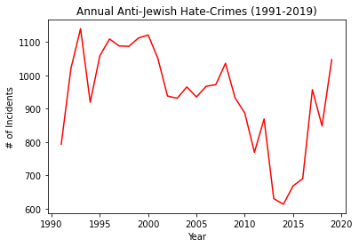

```python
plt.plot(AJ_total_per_year.index, AJ_total_per_year["total # of hate crimes"], color='r', label="Total")
plt.xlabel("Year")
plt.ylabel("# of Incidents")
plt.title("Annual Anti-Jewish Hate-Crimes (1991-2019)")
```

The plot shows a steep drop in incidnets folowing the year 2000, then a series of peeks and valleys in the years following, and a steep increase in 2017. Lets plot the total number of hate crimes from 1991 to 2019 to see how the graphs compare.

```python
#creat a dataframe for yearly hate crime totals
years=list(range(1991, 2020))
d={"year":years, "total # of hate crimes":([0]*29)}
total_per_year=pd.DataFrame(data=d)
total_per_year=total_per_year.set_index("year")
for row in FBI_91_19.iterrows():
    year=row[1]["DATA_YEAR"]
    total_per_year.loc[year]["total # of hate crimes"] = total_per_year.loc[year]["total # of hate crimes"]+1
```

```python
#plot yearly total hate crimes
plt.plot(total_per_year.index, total_per_year["total # of hate crimes"], color='r', label="Total")
plt.xlabel("Year")
plt.ylabel("# of Incidents")
plt.title("Annual Total Hate-Crimes (1991-2019)")
```

[output not shown]

The graph of annual total hate crimes shows a number of peaks and valleys in the data. The graph shows that the number of incidents hit its peak in 2001 followed by a general decease in incidents in the years following with 2014 having the fewest incidents since 1991 and a a mulpiple year increse between 2015 and 2019. Moing forward we are going to focus on the years between 2000 and 2019.

```python
#make a dataframe to specifically hold anti-jeish hate cimes for the years 2000 and 2019
annual_2000s=AJ_total_per_year[AJ_total_per_year.index >= 2000]
#plot the number of incidents for the years 2000 to 2019
fig, ax=plt.subplots()
ax.xaxis.set_major_locator(ticker.MaxNLocator(integer=True)) #I'm including this line so that the marks for the years are at integers points
ax.plot(annual_2000s.index, annual_2000s["total # of hate crimes"])
#make sure your graphs and axies are properly labled!
ax.set_xlabel("Year")
ax.set_ylabel("# of Incidents")
ax.set_title("Annual Anti-Jewish Hate-Crimes (2000-2019)")
```

[output not shown]

Now that we have an idea of the genral trends in terms of the total number of incidents per year, I'm curious how the incidents specific characteristics and what the break down look like. I am interested in how many Anti-Jewish incidents are directed against individauls and how many are directed agiainst Religious Organizations, and what the ratios are tot he total number of incidents.

One feature of matlibplot that I am goining to utilize is the ability to make a fugure comprised of multiple subplots. This allows me to group relavent plots together and see them in one place, making it easier to see how the plots compare.

```python
#creat a figure made up of 2 rows of 2 plots each;
#each plot will be refered to by it's location in the figure
fig, axes = plt.subplots(2,2, figsize=(15,10))
axes[0][0].xaxis.set_major_locator(ticker.MaxNLocator(integer=True))
axes[0][1].xaxis.set_major_locator(ticker.MaxNLocator(integer=True))
axes[1][0].xaxis.set_major_locator(ticker.MaxNLocator(integer=True))
axes[1][1].xaxis.set_major_locator(ticker.MaxNLocator(integer=True))

#in the first graph we are going to plot the number of incidents against individuals per year
axes[0][0].plot(annual_2000s.index, annual_2000s["against individuals"])
axes[0][0].set_xlabel("Years")
axes[0][0].set_ylabel("# of incidents")
axes[0][0].set_title("Number of Anti-Jewish Hate-Crimes Against Individuals")

#in the second graph we are going to plot the number of incidents against Religious Organizations per year
axes[0][1].plot(annual_2000s.index, annual_2000s["against Religious Organizations"])
axes[0][1].set_xlabel("Years")
axes[0][1].set_ylabel("# of incidents")
axes[0][1].set_title("Number of Anti-Jewish Hate-Crimes Against Religious Organizations")

#in the third graph we are going to plot the ratio of incidents directed against individauls to the total number of incedents per year as a percentage
axes[1][0].plot(annual_2000s.index, annual_2000s["indivitual to total"])
axes[1][0].set_xlabel("Years")
axes[1][0].set_ylabel("Incidnets Agianst Individuals (%)")
axes[1][0].set_title("Anti-Jewish Hate-Crimes Against Individuals by Percentage")

#in the fourth graph we are going to plot the ratio of incidents directed against Religious Organizations to the total number of incedents per year as a percentage
axes[1][1].plot(annual_2000s.index, annual_2000s["Religious Organization to total"])
axes[1][1].set_xlabel("Years")
axes[1][1].set_ylabel("Incidnets Agianst Religious Organizations (%)")
axes[1][1].set_title("Anti-Jewish Hate-Crimes Against Religious Organizations by Percentage")
```

[output not shown]

## Hypothesis Testing

Now that we have gathered our data, cleaned it up and done some exploritory analysis, it's time to test our hypothesis. The hypothesis that we will be testing is that there was no change in Anti_Jewish hae crimes in the wake of the 2016 U.S. Presidential elections.

I am going to break up my data in to two dataframes, one will be Anti-Jewish hate crimes between the years 2000-2015 and the second will be Anti-Jewish hate crimes between the years 2016-2019. I am goint to plot a linear regression for each group to see the greneral trend in the direction of growth in Anti-Jewish hate crimes in both time frames.

I am going to use sklearn's lnear regrssion model which plots a linear regression given varrious data points. You can learn more about sklearn's linear regression function here: https://scikit-learn.org/stable/modules/generated/sklearn.linear_model.LinearRegression.html.

```python
#creat a data frame of Anti-Jewish hate cromes 2000-2015
annual_pre_2016=annual_2000s[annual_2000s.index <= 2015]

fig, ax=plt.subplots()
ax.xaxis.set_major_locator(ticker.MaxNLocator(integer=True))

#plot the linear regression for the years 2000-2015
years=np.asarray(range(2000, 2016))
years=years.reshape(-1,1)
regr2000= LinearRegression()
regr2000.fit(years,annual_pre_2016["total # of hate crimes"])
pred=regr2000.predict(years)
ax.plot(years, pred, color="red")

#pot the actual data as a scatter plot in the same graph
ax.scatter(annual_pre_2016.index, annual_pre_2016["total # of hate crimes"], color="b")

#don't forget to lable evrything
ax.set_xlabel("Year")
ax.set_ylabel("# of Incidents")
ax.set_title("Annual Anti-Jewish Hate-Crimes (2000-2019)")

#creat a data frame of Anti-Jewish hate cromes 2015-2019
annual_post_2016=annual_2000s[annual_2000s.index > 2015]

#plot the linear regression for the years 2015-2019
years=np.asarray(range(2016, 2020))
years=years.reshape(-1,1)
regr2016= LinearRegression()
regr2016.fit(years,annual_post_2016["total # of hate crimes"])
pred=regr2016.predict(years)
ax.plot(years, pred, color="red")

#plot the actual data as a scatter plot in the same graph
ax.scatter(annual_post_2016.index, annual_post_2016["total # of hate crimes"], color="b")
```

[output not shown]

```python
# I'm going to get the slop change in the number of Anti-Jewish hate crimes for both sets of years (2000-2015 and 2016-2019)
# using the .coef_ of the linear regression of each
pre_2016_roc="rate of change pre-2016: " + str(regr2000.coef_)
post_2016_roc="rate of change post-2016: " + str(regr2016.coef_)
print(pre_2016_roc)
print(post_2016_roc)
```

[output not shown]

We see that between 2000 and 2016, the number of Anti-jewish Hate crimes have been droping on average by over 26 incedents per-year. After 2016 we see the number of Anti_Jewish hate crimes increase on average by over 90 incidents per year. This does not support the hypothesis that there was no change in anti-Jewish hatecrimes in the wake of the 2016 presidential eletions.

The linear regressions we ploted above showed us that over 15 years between 2000 and 2015 number of Anti-Jewish hate crimes is decreasing and that over the 4 years between 2016 and 2019 the number of Anti-Jewish hate crimes has been incresing, this shows us that between the years 2016 and 2019 there was a spike in hate crimes but not much else. I would like to compare the recent spike in incidents to the spikes in 2005-2008 and 2011-2012 to see if this recent spike is larger, and persists for longer than previous spikes in hate crime incidents.

I am going to make a data frame for each range of years entioed above and plot a linear regression for each, like I did in the previous graph.

```python
annual_05_08
```

```python
#creat a data frame of Anti-Jewish hate cromes 2000-2015
annual_05_08=annual_2000s[(annual_2000s.index <= 2008) & (annual_2000s.index >= 2005)]

fig, ax=plt.subplots()
ax.xaxis.set_major_locator(ticker.MaxNLocator(integer=True))

#plot the linear regression for the years 2000-2015
years=np.asarray(range(2005, 2009))
years=years.reshape(-1,1)
regr05_08= LinearRegression()
regr05_08.fit(years,annual_05_08["total # of hate crimes"])
pred=regr05_08.predict(years)
ax.plot(years, pred, color="red")

#don't forget to lable evrything
ax.set_xlabel("Year")
ax.set_ylabel("# of Incidents")
ax.set_title("Annual Anti-Jewish Hate-Crimes (2000-2019)")

#creat a data frame of Anti-Jewish hate cromes 2011-2012
annual_11_12=annual_2000s[(annual_2000s.index <= 2012) & (annual_2000s.index >= 2011)]

#plot the linear regression for the years 2015-2019
years=np.asarray(range(2011, 2013))
years=years.reshape(-1,1)
regr11_12= LinearRegression()
regr11_12.fit(years,annual_11_12["total # of hate crimes"])
pred=regr11_12.predict(years)
ax.plot(years, pred, color="red")

#plot the linear regression for the years 2015-2019
years=np.asarray(range(2016, 2020))
years=years.reshape(-1,1)
regr2016= LinearRegression()
regr2016.fit(years,annual_post_2016["total # of hate crimes"])
pred=regr2016.predict(years)
ax.plot(years, pred, color="red")

#plot the actual data as a scatter plot in the same graph
ax.scatter(annual_2000s.index, annual_2000s["total # of hate crimes"], color="b")
```

[output not shown]

The above graph shows the rate of increase of incidents for each of the specified year ranges. Just by looking at the graph we can see that 2016-2019 has a steeper increase than 2005-2008. We can also see that 20016-2019 has a longer period of incease than 2011-2012; there are 3 years of incease followed by a drop in 2018 and another sharp increase in 2019. Lets look at the coficients of the linear regressions to get a better understanding of the rate of change for each time period.

```python
roc_05_08="rate of change 2005-2008: " + str(regr05_08.coef_)
roc_11_12="rate of change 2011-2012: " + str(regr11_12.coef_)
post_2016_roc="rate of change post-2016: " + str(regr2016.coef_)
print(roc_05_08)
print(roc_11_12)
print(post_2016_roc)
```

[output not shown]

The coeficients show that the increse happening in 2016-2019 is over 3x that of 2005-2008. It also shows that the rate of increse in 2016-2019 is slightly less than that of 2011-2012, although that is in part due to the breif dip in 2018, I bleive if we looked at 2016-2017 and 2018-2019 seperatly both would have larger rates of increase compared to 2011-2012.

## Subjective Evaluation

I believe that my project is both polished and "polishable". I have spend alot of time polishing my project. I have found the most creadable and substantial data on the topic, I did reaserch to show that it is an issue that is of real importance to many, my code is clear and consice, my prose is well writen, easy o understand and conveys usefull information. This tutorial had undergone a number of iterations of editing and refinment to make it well put together, informative, and a resource for other to learn anout the data scince pipeline.